# Assignment 4 - Visual Exploration & Analysis of Strava Data

In this notebook, I will explore and provide insights on the Strava data collected by Professor Christopher Brooks. A scatter plot matrix will be created to provide an overview of the data, bar plots will be created to present key metrics, box plots will be created to show the weekly distribution of activity intensity, and an interactive folium heat map will be created to display the path of all routes taken.

## Step 1 - Import Necessary Libraries and data

Pandas will be used to clean the data; Matplotlib and Seaborn will be used to visualize it.

```python
import pandas as pd
import matplotlib.pyplot as plt
import seaborn as sns
```

Read the information from strava.csv into a dataframe called df.

The following pieces of data are included: 'Air Power', 'Cadence', 'Form Power', 'Ground Time', 'Leg Spring Stiffness', 'Power', 'Vertical Oscillation', 'altitude', 'cadence', 'datafile', 'distance', 'enhanced_altitude', 'enhanced_speed', 'fractional_cadence', 'heart_rate', 'position_lat', 'position_long', 'speed', 'timestamp', 'unknown_87', 'unknown_88', and 'unknown_90'

For the purpose of this assignment, I will only be looking at 'cadence' (rpm), 'datafile', 'distance' (m to be converted to miles), 'enhanced_altitude' (m above sea level), 'enhanced_speed' (m/s), 'heart_rate' (BPM), 'position_lat','position_long', and 'timestamp.'

```python
#Import Data
df = pd.read_csv('strava.csv')
#convert distance from m to miles
df['distance'] /= 1600   #1600 m in a mile
df.head()
```

|  | Air Power | Cadence | Form Power | Ground Time | Leg Spring Stiffness | Power | Vertical Oscillation | altitude | cadence | datafile | ... | enhanced_speed | fractional_cadence | heart_rate | position_lat | position_long | speed | timestamp | unknown_87 | unknown_88 | unknown_90 |
| --- | --- | --- | --- | --- | --- | --- | --- | --- | --- | --- | --- | --- | --- | --- | --- | --- | --- | --- | --- | --- | --- |
| 0 | NaN | NaN | NaN | NaN | NaN | NaN | NaN | NaN | 0.0 | activities/2675855419.fit.gz | ... | 0.000 | 0.0 | 68.0 | NaN | NaN | 0.0 | 2019-07-08 21:04:03 | 0.0 | 300.0 | NaN |
| 1 | NaN | NaN | NaN | NaN | NaN | NaN | NaN | NaN | 0.0 | activities/2675855419.fit.gz | ... | 0.000 | 0.0 | 68.0 | NaN | NaN | 0.0 | 2019-07-08 21:04:04 | 0.0 | 300.0 | NaN |
| 2 | NaN | NaN | NaN | NaN | NaN | NaN | NaN | NaN | 54.0 | activities/2675855419.fit.gz | ... | 1.316 | 0.0 | 71.0 | NaN | NaN | 1316.0 | 2019-07-08 21:04:07 | 0.0 | 300.0 | NaN |
| 3 | NaN | NaN | NaN | NaN | NaN | NaN | NaN | 3747.0 | 77.0 | activities/2675855419.fit.gz | ... | 1.866 | 0.0 | 77.0 | 504432050.0 | -999063637.0 | 1866.0 | 2019-07-08 21:04:14 | 0.0 | 100.0 | NaN |
| 4 | NaN | NaN | NaN | NaN | NaN | NaN | NaN | 3798.0 | 77.0 | activities/2675855419.fit.gz | ... | 1.894 | 0.0 | 80.0 | 504432492.0 | -999064534.0 | 1894.0 | 2019-07-08 21:04:15 | 0.0 | 100.0 | NaN |

5 rows × 22 columns

Each time strava was turned on for an activity, Strava would periodically record data from the various sensors, along with the timestamp. This results in thousands of data points fore each fit file, but this doesn't necessarily mean that just one datafile was created for each activity. There are instances that professor Brooks stopped recording data during a given workout, be it for a break or some other reason, and later resumed recording data — under a different fit file.

Hence, I grouped the data by datafile, and if the difference between the start of one data file was more than an hour apart from the end of the previous datafile, I considered the datafiles to be recording data for different events.

Differentiating between different activites like this reveal that 64 datafiles were created for 51 different workouts.

```python
df1 = df[['datafile', 'timestamp']]
df1['timestamp'] = pd.to_datetime(df['timestamp']) #Convert timestamp to datetime format
df2 = df1.groupby('datafile').timestamp.agg({'min','max'}).reset_index()
df2['time_diff'] = (df2['min']-df2['max'].shift()).fillna(pd.Timedelta(seconds=0)) #Find timedelta between min of row and max of previous
df2['time_diff'] = df2['time_diff'].dt.total_seconds() / 3600.0 #Convert timedelta object to hours

count = 1 #Initialize count
#Create function to apply to time diff and check for different events
def event_count(x):
    global count
    if x >= 1.0:
        count += 1
    return count

df2['event'] = df2['time_diff'].apply(event_count)
df2.head(10)
#64 datafiles and 51 separate events
```

|  | datafile | max | min | time_diff | event |
| --- | --- | --- | --- | --- | --- |
| 0 | activities/2675855419.fit.gz | 2019-07-08 21:23:55 | 2019-07-08 21:04:03 | 0.000000 | 1 |
| 1 | activities/2677658978.fit.gz | 2019-07-10 23:23:09 | 2019-07-10 23:18:00 | 49.901389 | 2 |
| 2 | activities/2677658993.fit.gz | 2019-07-10 23:30:10 | 2019-07-10 23:24:57 | 0.030000 | 2 |
| 3 | activities/2677659014.fit.gz | 2019-07-10 23:37:20 | 2019-07-10 23:31:42 | 0.025556 | 2 |
| 4 | activities/2682705331.fit.gz | 2019-07-12 22:30:17 | 2019-07-12 21:27:11 | 45.830833 | 3 |
| 5 | activities/2688518063.fit.gz | 2019-07-14 18:38:22 | 2019-07-14 17:20:28 | 42.836389 | 4 |
| 6 | activities/2688898988.fit.gz | 2019-07-14 21:04:51 | 2019-07-14 20:45:07 | 2.112500 | 5 |
| 7 | activities/2694503073.fit.gz | 2019-07-16 21:15:21 | 2019-07-16 21:10:40 | 48.096944 | 6 |
| 8 | activities/2694503189.fit.gz | 2019-07-16 21:29:10 | 2019-07-16 21:16:49 | 0.024444 | 6 |
| 9 | activities/2697739124.fit.gz | 2019-07-17 23:52:56 | 2019-07-17 23:17:06 | 25.798889 | 7 |

I used pd.merge to map the workout event info back to the initial dataframe with all information and then reduced the columns down to what I am interested in analyzing.

```python
df2 = pd.merge(df, df2, on='datafile')
```

```python
#Remove info I am not interested in
df3 = df2[[
       'cadence', 'datafile', 'distance', 'enhanced_altitude',
       'enhanced_speed','heart_rate','timestamp','max', 'min', 'time_diff', 'event']]
#df3.head()
```

For each activity, I want to know the start and end time, miles traveled, avereage cadence, average speed, average altitude, and average heart rate.

Because each event may have several datafiles, I first grouped by both event and datafile, and then grouped by event again to have just one row of data for each workout.

```python
#Don't need the datafile for analyzing start time, end time, distance, average cadence, average speed, average altitude, and average heart rate
#Distance is cumulative, so I took the highest value
data_by_event = df3.groupby(['event', 'datafile']).agg({'min':'min','max':'max','distance':'max', 'cadence': 'mean','enhanced_speed':'mean', 'enhanced_altitude':'mean', 'heart_rate':'mean'})
#Group by event again on new dataframe to add up distances
data_by_event = data_by_event.groupby('event').agg({'min':'min','max':'max','distance':'sum', 'cadence': 'mean','enhanced_speed':'mean', 'enhanced_altitude':'mean', 'heart_rate':'mean'})
data_by_event.columns = ['start', 'end', 'distance_in_miles', 'average_cadence', 'average_speed', 'average_altitude', 'average_heart_rate']
#data_by_event.head()
```

Professor Brooks recorded data for both biking and running, so I want to identify each event as a running or biking workout.

According to Strava insights, the average speed for a U.S. male cyclist is 14.6 mph (6.5 m/s), and theaverage pace for U.S. male runner is 9:03/mile (3 m/s). Based on this info, I categorized each workout as being a biking workout if the average speed was greater than 4.5 m/s and a run if the average speed was slower.

The data shows that professor brooks started biking on September 12th on the 42nd workout recorded. This lines up with what he said about getting injured by running and buying a bike in September.

```python
data_by_event['activity'] = data_by_event['average_speed'].apply(lambda x: 'bike' if x > 4.5 else 'run')

data_by_event.tail(15)
```

| event | start | end | distance_in_miles | average_cadence | average_speed | average_altitude | average_heart_rate | activity |
| --- | --- | --- | --- | --- | --- | --- | --- | --- |
| 37 | 2019-08-21 03:24:16 | 2019-08-21 03:58:43 | 3.262281 | 79.345111 | 2.528938 | 294.287222 | 153.681994 | run |
| 38 | 2019-08-23 01:24:39 | 2019-08-23 02:07:00 | 3.752144 | 77.948859 | 2.356642 | 289.964910 | 138.961448 | run |
| 39 | 2019-08-24 19:36:17 | 2019-08-24 19:57:56 | 1.802237 | 73.600000 | 2.238753 | 271.647077 | 124.924615 | run |
| 40 | 2019-08-28 21:41:28 | 2019-08-28 21:54:53 | 1.310606 | 76.714640 | 2.621478 | 269.115881 | 143.183623 | run |
| 41 | 2019-08-31 18:45:43 | 2019-08-31 19:15:29 | 3.128437 | 80.588565 | 2.822718 | 293.309305 | 154.515695 | run |
| 42 | 2019-09-12 00:09:40 | 2019-09-12 00:45:32 | 6.840250 | 47.206000 | 5.010060 | 252.176447 | 121.892216 | bike |
| 43 | 2019-09-14 20:08:40 | 2019-09-14 21:37:39 | 18.659275 | 63.940277 | 6.404401 | 258.689505 | 133.803855 | bike |
| 44 | 2019-09-15 21:14:22 | 2019-09-15 22:24:19 | 8.318513 | 56.377642 | 5.543921 | 268.130907 | NaN | bike |
| 45 | 2019-09-16 20:47:19 | 2019-09-16 21:59:45 | 17.860894 | 68.665335 | 6.365662 | 252.722877 | 125.924547 | bike |
| 46 | 2019-09-23 20:55:51 | 2019-09-23 21:31:09 | 8.134019 | 63.075571 | 5.903938 | 264.360633 | 131.168717 | bike |
| 47 | 2019-09-25 18:27:37 | 2019-09-25 19:44:34 | 8.339756 | 22.875735 | 5.574316 | 249.970596 | NaN | bike |
| 48 | 2019-09-25 21:42:05 | 2019-09-25 22:29:29 | 9.754300 | 15.207906 | 5.473069 | 271.078736 | 132.779221 | bike |
| 49 | 2019-09-28 21:51:12 | 2019-09-28 22:20:01 | 7.598637 | 72.507426 | 7.069993 | 255.348515 | 143.824257 | bike |
| 50 | 2019-09-30 21:25:34 | 2019-09-30 23:04:02 | 24.379450 | 66.728424 | 6.547386 | 259.955924 | NaN | bike |
| 51 | 2019-10-03 21:30:03 | 2019-10-03 23:05:05 | 24.157869 | 69.295019 | 6.592298 | 258.252874 | 135.955556 | bike |

## Step 2 - Get an Overview of the Data with a Scatterplot Matrix (SPLOM)

Scatterplot matrices (SPLOMs) can be created with seaborns pairplot function to quickly generate a grid of scatterplots that compare each data point of interest. Density plots are created on the diagonals showing the distributions of a given variable.

sns.pairplot() also comes with a hue parameter that will be used to differentiate data points as being from a biking or running workout.

Creating this matix allows for a broad overview of all datapoints of interest.

```python
splom_df = data_by_event[['distance_in_miles', 'average_cadence', 'average_speed', 'average_altitude', 'average_heart_rate', 'activity']]
splom_df.head()
```

| event | distance_in_miles | average_cadence | average_speed | average_altitude | average_heart_rate | activity |
| --- | --- | --- | --- | --- | --- | --- |
| 1 | 1.635913 | 74.406504 | 2.088154 | 264.607407 | 118.337398 | run |
| 2 | 1.582706 | 79.495604 | 2.580118 | 255.467821 | 130.760556 | run |
| 3 | 4.671037 | 74.135016 | 1.966212 | 270.951043 | 117.687157 | run |
| 4 | 5.295175 | 74.465381 | 1.785065 | 275.517967 | 110.975460 | run |
| 5 | 1.633325 | 79.705686 | 2.078495 | 269.804682 | 123.819398 | run |

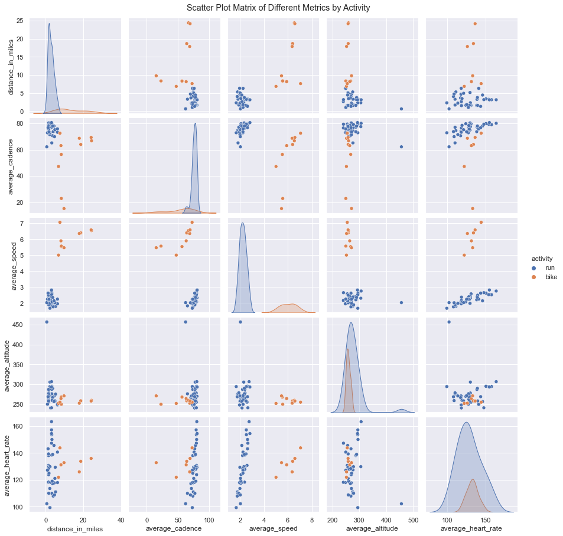

```python
%matplotlib inline
sns.set_theme(style="darkgrid")
g = sns.pairplot(splom_df, hue='activity')
g.fig.suptitle("Scatter Plot Matrix of Different Metrics by Activity", y=1.01)
```

The following observations can be made:

```
Biking and running data had two distinct speed populations, which could have been guessed intuitively.

There is a positive correlation between heart rate and speed. The faster Chris moved, the more his heart rate reflected the workout intensity.

There is greater variation in distance for biking. It makes sense that can Chris can travel as little as he wants, but can travel much further by biking than running.

Chris had a greater variation in heart rate while running than biking. Chris went from being a beginner runner to overtraining to the point of injury, so it makes sense that the upper range
of his running heart rate could be considered extreme. More on that later.
```

## Step 3 - Provide Key Metrics with Seaborn Bar Plots

To serve as a testament to his hard work and dedication to fitness, Chris may be interested in learning more about how many workouts of each type he had, how long he spent working out, and how many miles he traveled. He also may be interested in the amount of calories he burns, since that information can be used to determine the appropriate diet adjustments he needs to make in order to achieve his fitness goals. Such information can be conveyed easily through barplots.

I now want to create datapoints of the calories burned and the duration for each workout. The equation for calories burned is((-55.0969 + (0.6309 × heart rate) + (0.1988 × weight(kg)) + (0.2017 × age)) / 4.184) × 60 × duration(hours) At the time the data points were recorded, Chris was 41, and although he did not give the weight, I made the assumption that he is 80.3 kg of Canadian Muscle. (the average mass of a Canadian man)

```python
data_by_event.head()
#Find calories burned
#Height is ~183cm, age is 41 for that data (sept 5/78), for weight let me pull it (80.3 kg (177 lb) is average for Canadian man)
#Create column for duration
data_by_event['duration_in_hours'] = (pd.to_datetime(data_by_event['end']) - pd.to_datetime(data_by_event['start'])).dt.total_seconds() / 3600.0

#Use following equation to determine calories lost: ((-55.0969 + (0.6309 × heart rate) + (0.1988 × weight(kg)) + (0.2017 × age)) / 4.184) × 60 × duration(hours)
data_by_event['calories_burned'] = ((-55.0969 + (0.6309 * data_by_event.average_heart_rate) + (0.1988 * 80.3) + (0.2017 * 41)) / 4.184) * 60 * data_by_event.duration_in_hours
data_by_event.head()
```

| event | start | end | distance_in_miles | average_cadence | average_speed | average_altitude | average_heart_rate | activity | duration_in_hours | calories_burned |
| --- | --- | --- | --- | --- | --- | --- | --- | --- | --- | --- |
| 1 | 2019-07-08 21:04:03 | 2019-07-08 21:23:55 | 1.635913 | 74.406504 | 2.088154 | 264.607407 | 118.337398 | run | 0.331111 | 207.951886 |
| 2 | 2019-07-10 23:18:00 | 2019-07-10 23:37:20 | 1.582706 | 79.495604 | 2.580118 | 255.467821 | 130.760556 | run | 0.322222 | 238.585878 |
| 3 | 2019-07-12 21:27:11 | 2019-07-12 22:30:17 | 4.671037 | 74.135016 | 1.966212 | 270.951043 | 117.687157 | run | 1.051667 | 654.304581 |
| 4 | 2019-07-14 17:20:28 | 2019-07-14 18:38:22 | 5.295175 | 74.465381 | 1.785065 | 275.517967 | 110.975460 | run | 1.298333 | 728.932080 |
| 5 | 2019-07-14 20:45:07 | 2019-07-14 21:04:51 | 1.633325 | 79.705686 | 2.078495 | 269.804682 | 123.819398 | run | 0.328889 | 222.868277 |

```python
#Create dataframe with sums of activity count, calories, distance, and duration
#Seaborn doesn't create a Total column for comparison
sums = data_by_event.groupby('activity').agg({'calories_burned':'sum', 'distance_in_miles':'sum', 'duration_in_hours':'sum'}).reset_index()
sums['count'] = sums.activity.apply(lambda x: len(data_by_event[data_by_event.activity == x]))
sums.loc['Total'] = sums.sum()
sums.activity.replace('bikerun', 'Total',inplace=True)
#sums
```

Seaborn was used to create the barplots, and matplotlib was used to annotate.

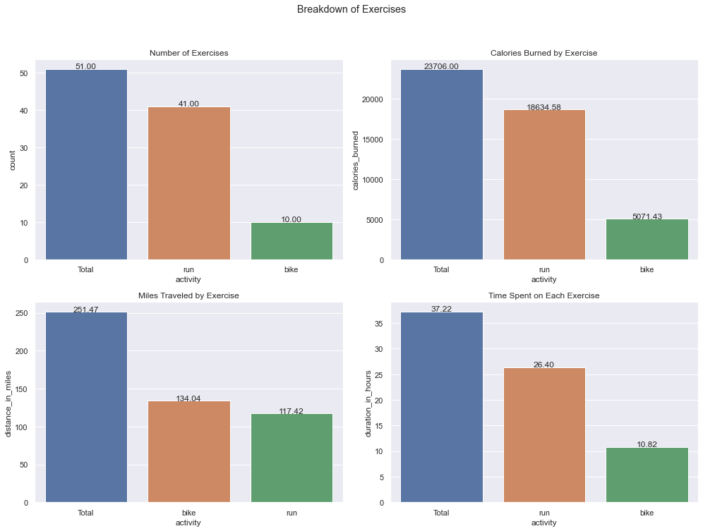

```python
#Interesting metrics to look at:
# # of workouts of each type
# #Total Calores Burned
# # Total distance traveled
# #Time Spent
fig, axes = plt.subplots(2, 2, figsize=(14,11))
sns.barplot(ax=axes[0,0], data=sums, x='activity', y='count', order=['Total','run','bike']).set_title('Number of Exercises')
sns.barplot(ax=axes[0,1], data=sums, x='activity', y='calories_burned', order=['Total','run','bike']).set_title('Calories Burned by Exercise')
sns.barplot(ax=axes[1,0], data=sums, x='activity', y='distance_in_miles', order=['Total','bike','run']).set_title('Miles Traveled by Exercise')
sns.barplot(ax=axes[1,1], data=sums, x='activity', y='duration_in_hours', order=['Total','run','bike']).set_title('Time Spent on Each Exercise')

#Add Data Labels
for row in [0,1]:
    for col in [0,1]:
        for p in axes[row,col].patches:
            height = p.get_height()
            axes[row,col].text(p.get_x()+p.get_width()/2.,
                    height + .1,
                    '{:1.2f}'.format(height),
                    ha="center")

fig.suptitle('Breakdown of Exercises')
#Fix Spacing
plt.tight_layout(rect=[0,.03,1,.95])
```

The following insights can be made:

```
1. Chris had 51 workouts, 41 of which were runs and 10 which were bike rides.
2. Chris burned 23,706 calories total, 18,635 which came from running
3. Chris traveled 251.5 miles, most of which came from biking, despite only biking ten times.
4. Chris spent 37 hours being active, 26 of which came from running.
```

Using the calories burned information, Chris burned an average of 465 calories per workout. If Chris wants to maintain weight, he should eat roughly 465 calories above maintenance on days that he works out. The exact calorie count can be adjusted per his goals.

## Step 4 - Create Box Plots to Show Weekly Distribution of Workout Intensity.

Chris Mentioned on the Slack Channel that he picked up biking in September after getting injured, so I want to further analyze his workout intensity to check for signs of overtraining. One indicator of workout intensity can be his average heart rate per workout. To make that information more digestable, I broke the data down by week of the year

```python
#Which heart rate zones was the most time spent in?
#df3 has all timestamps, so you can create box plots of the heart rate for each session
event_and_hr = df3[['event', 'timestamp', 'heart_rate','enhanced_speed']]
event_and_hr['activity'] = event_and_hr['event'].apply(lambda x: 'bike' if x >= 42 else 'run') #df3 shows that Chris switched to biking in September
event_and_hr['timestamp'] = pd.to_datetime(event_and_hr['timestamp']) #(event_and_hr['timestamp']).dt.strftime('%W') #Break Time by week
event_and_hr['Week_of_Year'] = event_and_hr['timestamp'].apply(lambda x : x.isocalendar()[1]) #Get Week of Year
event_and_hr.head()
```

|  | event | timestamp | heart_rate | enhanced_speed | activity | Week_of_Year |
| --- | --- | --- | --- | --- | --- | --- |
| 0 | 1 | 2019-07-08 21:04:03 | 68.0 | 0.000 | run | 28 |
| 1 | 1 | 2019-07-08 21:04:04 | 68.0 | 0.000 | run | 28 |
| 2 | 1 | 2019-07-08 21:04:07 | 71.0 | 1.316 | run | 28 |
| 3 | 1 | 2019-07-08 21:04:14 | 77.0 | 1.866 | run | 28 |
| 4 | 1 | 2019-07-08 21:04:15 | 80.0 | 1.894 | run | 28 |

Box plots were created with Seaborn and annotated with Matplotlib to visualize the distribution of heart rate data for each week in 2019 that data was collected for. Workout intensity zones based on heart rate are also shown. The workout intensity zones are based on the below chart, with the max heart rate that Chris should ever safely reach being 184.76 BPM.

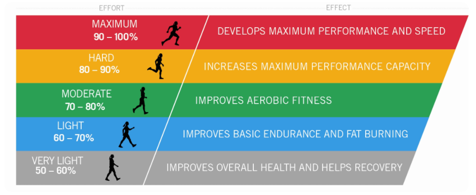

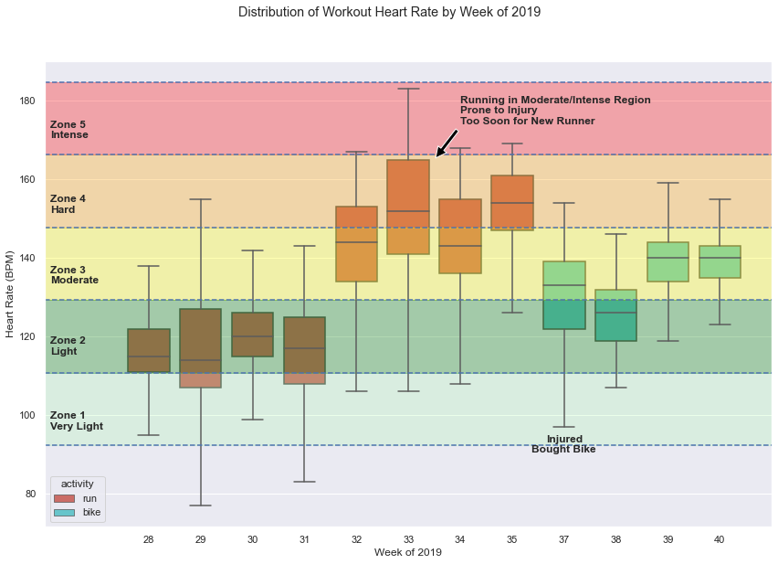

```python
sns.set(rc={'figure.figsize':(12,9)})


sns.boxplot(x="Week_of_Year", y="heart_rate", hue="activity",
                 data=event_and_hr, palette='hls', showfliers=False, dodge=False) #Remove outliers by setting showfliers to False

#Create lines for Heart Rate Zones
plt.axhline(184.76, ls='--') #Maximum
plt.axhline(184.76*.9, ls='--') #Maximum Lower
plt.fill_between([-2,13], y1= 184.76, y2= 184.76*.9, color='red',alpha=.3)
plt.axhline(184.76 * .8, ls='--') #Hard Lower
plt.fill_between([-2,13], y1= 184.76*.8, y2= 184.76*.9, color='orange',alpha=.3)
plt.axhline(184.76 * .7, ls='--') #Moderate Lower
plt.fill_between([-2,13], y1= 184.76*.7, y2= 184.76*.8, color='yellow',alpha=.3)
plt.axhline(184.76 * .6, ls='--') #Light Lower
plt.fill_between([-2,13], y1= 184.76*.6, y2= 184.76*.7, color='green',alpha=.3)
plt.axhline(184.76 * .5, ls='--') #Very Light Lower
plt.fill_between([-2,13], y1= 184.76*.5, y2= 184.76*.6, color='palegreen',alpha=.2)

#Annotate Fitness Zones
plt.annotate('Zone 5\nIntense',xy=(-1.9, 175), weight='bold', ha='left', va='top')
plt.annotate('Zone 4\nHard',xy=(-1.9, 156), weight='bold', ha='left', va='top')
plt.annotate('Zone 3\nModerate',xy=(-1.9, 138), weight='bold', ha='left', va='top')
plt.annotate('Zone 2\nLight',xy=(-1.9, 120), weight='bold', ha='left', va='top')
plt.annotate('Zone 1\nVery Light',xy=(-1.9, 101), weight='bold', ha='left', va='top')
#Annotate Bike Change
plt.annotate('Injured\nBought Bike',xy=(8, 95), weight='bold', ha='center', va='top')
plt.annotate('Running in Moderate/Intense Region\nProne to Injury\nToo Soon for New Runner', xy=(5.5, 165), xytext=(6, 174), arrowprops=dict(facecolor='black', shrink=0.05),weight='bold')

plt.xlim(-2,12)

plt.xlabel('Week of 2019')
plt.ylabel('Heart Rate (BPM)')
plt.suptitle('Distribution of Workout Heart Rate by Week of 2019')
plt.tight_layout(rect=[0,.03,1,.95])
```

From the boxplots, it can be shown that Chris spent his first few weeks of running mostly in the light and very light intensity zones, which are good zones for a beginner runner to be in. Once Chris got more adept at running between weeks 32 and 35 he spent much more time with his heart rate in the moderate and hard intensity zones. While I admire the dedication, he spent more time in these zones than he could handle, as made evident by his injury between weeks 35 and 37. After that point, he bought a bike and only biked for the following weeks.

The main takeaway is that Chris needs to pay attention to his average workout intensity if he decides to return to running. Running is a sport where injuries sneak up on you, so a beginner runner should not drastically up the intensity of his or her workouts all of a sudden.

## Step 5 Create Interactive Heat Map with Folium Displaying Route of Each Workoout

Using the HeatMapWithTime plugin from the Folium library, I created an interactive map that displays the route of each of Chris's 51 workouts.

Before I can start mapping the coordinate points of each workout, I need to convert the latitude and longitude points from the given Strava files to the standard decimal format. This is done by multiplying by 180 degrees then dividing by 2 to the power of 31.

```python
df2["position_lat_degrees"] = df2["position_lat"] * ( 180 / 2**31 )
df2["position_long_degrees"] = df2["position_long"] * ( 180 / 2**31 )
df_map = df2[['position_lat_degrees','position_long_degrees','event']]
df_map = df_map.dropna() #NAs don't go well with Folium

df_map.head()
```

|  | position_lat_degrees | position_long_degrees | event |
| --- | --- | --- | --- |
| 3 | 42.281006 | -83.740547 | 1 |
| 4 | 42.281043 | -83.740622 | 1 |
| 5 | 42.281058 | -83.740629 | 1 |
| 6 | 42.281063 | -83.740644 | 1 |
| 7 | 42.281078 | -83.740660 | 1 |

Now Import the folium library and HeatMapWithTime plugin. Create a map with the location centered in Ann Arbor, MI, where the workouts took place. The HeatMapWithTime plugin can be used to create a heat Map of Chris's locations for each workout. Plot the heat map info on the map.

```python
import folium
from folium.plugins import HeatMapWithTime

#Create Map
m=folium.Map(location=[42.2869, -83.7438], zoom_start=14)

#Deal with floats
df_map['Latitude'] = df_map['position_lat_degrees'].astype(float)
df_map['Longitude'] = df_map['position_long_degrees'].astype(float)

# Filter the DF then remove NaNs
heat_df = df_map[['Latitude', 'Longitude']].dropna()

# Create weight column, using event
heat_df['event'] = df_map['event']
heat_df['event'] = heat_df['event'].astype(float)
heat_df = heat_df.dropna(axis=0, subset=['Latitude','Longitude', 'event'])

# List comprehension to make out list of lists
heat_data = [[[ row['Latitude'],row['Longitude']] for index, row in heat_df[heat_df['event'] == i].iterrows()] for i in range(1,52)]


# Plot it on the map
hm =HeatMapWithTime(heat_data,auto_play=True,max_opacity=0.8, radius=10)
hm.add_to(m)
# Display the map and save
m.save(outfile= "heatmap.html")
```

```python
from IPython.display import IFrame

IFrame(src='heatmap.html', width=1000, height=1000)
```

[interactive chart not shown]

This interactive map provides a repository of all of Chris' favorite routes. Having this visualization handy would allow Chris to easily make revisions to his workout routes, whether he wants to shorten or elongate a route, or just pass a certain landmark.

Note that the routes start getting longer around workout 42, when Chris transitions to biking. The distance between points also increases, since Chris is moving at a faster pace between Strava timestamps.